# Tmdb_Movies_Dataset_Redo

INVESTIGATE A DATASET

Tmdb_Movie Data

INTRODUCTION:

This project will be analysis dataset based on the movies and thier budgets with the revenues generated,genre,year of released,with each movie rating and voting

QUESTIONS TO ASK THE DATASET

1. Which director directed higher number of movie
2. Is movie popularity has to do with it profit generated
3. let us check relationship between revenue_adj and budget_adj
4. Which year has highest movies released
5. Which movie generated highest number of revenue

```python
#importing neccessary libraries like pandas, matplotlib and seaborn

import pandas as pd
import matplotlib.pyplot as plt
import seaborn as sns
%matplotlib inline
```

DATA WRANGLING

In this section of the report, I will load in the data, check for cleanliness, and then trim and clean the dataset for analysis. Make sure that I document data cleaning steps in mark-down cells precisely and justify cleaning decisions.

```python
# let load the dataset

data = pd.read_csv('movies.csv')
```

```python
#check the numbers of rows and columns of the dataset
data.shape
```

```
(10866, 21)
```

```python
#let us check out the dataset

data.head(2)
```

|  | id | imdb_id | popularity | budget | revenue | original_title | cast | homepage | director | tagline | ... | overview | runtime | genres | production_companies | release_date | vote_count | vote_average | release_year | budget_adj | revenue_adj |
| --- | --- | --- | --- | --- | --- | --- | --- | --- | --- | --- | --- | --- | --- | --- | --- | --- | --- | --- | --- | --- | --- |
| 0 | 135397 | tt0369610 | 32.985763 | 150000000 | 1513528810 | Jurassic World | Chris Pratt\|Bryce Dallas Howard\|Irrfan Khan\|Vi... | http://www.jurassicworld.com/ | Colin Trevorrow | The park is open. | ... | Twenty-two years after the events of Jurassic ... | 124 | Action\|Adventure\|Science Fiction\|Thriller | Universal Studios\|Amblin Entertainment\|Legenda... | 06-09-15 | 5562 | 6.5 | 2015 | 137999939.3 | 1.392446e+09 |
| 1 | 76341 | tt1392190 | 28.419936 | 150000000 | 378436354 | Mad Max: Fury Road | Tom Hardy\|Charlize Theron\|Hugh Keays-Byrne\|Nic... | http://www.madmaxmovie.com/ | George Miller | What a Lovely Day. | ... | An apocalyptic story set in the furthest reach... | 120 | Action\|Adventure\|Science Fiction\|Thriller | Village Roadshow Pictures\|Kennedy Miller Produ... | 5/13/15 | 6185 | 7.1 | 2015 | 137999939.3 | 3.481613e+08 |

2 rows × 21 columns

```python
# check the information about the data types of each columns
data.info()
```

```
<class 'pandas.core.frame.DataFrame'>
RangeIndex: 10866 entries, 0 to 10865
Data columns (total 21 columns):
 #   Column                Non-Null Count  Dtype
---  ------                --------------  -----
 0   id                    10866 non-null  int64
 1   imdb_id               10856 non-null  object
 2   popularity            10866 non-null  float64
 3   budget                10866 non-null  int64
 4   revenue               10866 non-null  int64
 5   original_title        10866 non-null  object
 6   cast                  10790 non-null  object
 7   homepage              2936 non-null   object
 8   director              10822 non-null  object
 9   tagline               8042 non-null   object
 10  keywords              9373 non-null   object
 11  overview              10862 non-null  object
 12  runtime               10866 non-null  int64
 13  genres                10843 non-null  object
 14  production_companies  9836 non-null   object
 15  release_date          10866 non-null  object
 16  vote_count            10866 non-null  int64
 17  vote_average          10866 non-null  float64
 18  release_year          10866 non-null  int64
 19  budget_adj            10866 non-null  float64
 20  revenue_adj           10866 non-null  float64
dtypes: float64(4), int64(6), object(11)
memory usage: 1.7+ MB
```

From the look of the dataset the dataset is not proper for analysis, needs some touch of cleaning.

CLEANING POINTS . Drop empty rows . Change realise_date column from object to datetime . Drop some of irrelevant columns

```python
#to check for the total of duplicates in the dataset
data.duplicated().sum()
```

```
1
```

```python
#let remove the duplicate
data.drop_duplicates()
```

|  | id | imdb_id | popularity | budget | revenue | original_title | cast | homepage | director | tagline | ... | overview | runtime | genres | production_companies | release_date | vote_count | vote_average | release_year | budget_adj | revenue_adj |
| --- | --- | --- | --- | --- | --- | --- | --- | --- | --- | --- | --- | --- | --- | --- | --- | --- | --- | --- | --- | --- | --- |
| 0 | 135397 | tt0369610 | 32.985763 | 150000000 | 1513528810 | Jurassic World | Chris Pratt\|Bryce Dallas Howard\|Irrfan Khan\|Vi... | http://www.jurassicworld.com/ | Colin Trevorrow | The park is open. | ... | Twenty-two years after the events of Jurassic ... | 124 | Action\|Adventure\|Science Fiction\|Thriller | Universal Studios\|Amblin Entertainment\|Legenda... | 06-09-15 | 5562 | 6.5 | 2015 | 1.379999e+08 | 1.392446e+09 |
| 1 | 76341 | tt1392190 | 28.419936 | 150000000 | 378436354 | Mad Max: Fury Road | Tom Hardy\|Charlize Theron\|Hugh Keays-Byrne\|Nic... | http://www.madmaxmovie.com/ | George Miller | What a Lovely Day. | ... | An apocalyptic story set in the furthest reach... | 120 | Action\|Adventure\|Science Fiction\|Thriller | Village Roadshow Pictures\|Kennedy Miller Produ... | 5/13/15 | 6185 | 7.1 | 2015 | 1.379999e+08 | 3.481613e+08 |
| 2 | 262500 | tt2908446 | 13.112507 | 110000000 | 295238201 | Insurgent | Shailene Woodley\|Theo James\|Kate Winslet\|Ansel... | http://www.thedivergentseries.movie/#insurgent | Robert Schwentke | One Choice Can Destroy You | ... | Beatrice Prior must confront her inner demons ... | 119 | Adventure\|Science Fiction\|Thriller | Summit Entertainment\|Mandeville Films\|Red Wago... | 3/18/15 | 2480 | 6.3 | 2015 | 1.012000e+08 | 2.716190e+08 |
| 3 | 140607 | tt2488496 | 11.173104 | 200000000 | 2068178225 | Star Wars: The Force Awakens | Harrison Ford\|Mark Hamill\|Carrie Fisher\|Adam D... | http://www.starwars.com/films/star-wars-episod... | J.J. Abrams | Every generation has a story. | ... | Thirty years after defeating the Galactic Empi... | 136 | Action\|Adventure\|Science Fiction\|Fantasy | Lucasfilm\|Truenorth Productions\|Bad Robot | 12/15/15 | 5292 | 7.5 | 2015 | 1.839999e+08 | 1.902723e+09 |
| 4 | 168259 | tt2820852 | 9.335014 | 190000000 | 1506249360 | Furious 7 | Vin Diesel\|Paul Walker\|Jason Statham\|Michelle ... | http://www.furious7.com/ | James Wan | Vengeance Hits Home | ... | Deckard Shaw seeks revenge against Dominic Tor... | 137 | Action\|Crime\|Thriller | Universal Pictures\|Original Film\|Media Rights ... | 04-01-15 | 2947 | 7.3 | 2015 | 1.747999e+08 | 1.385749e+09 |
| ... | ... | ... | ... | ... | ... | ... | ... | ... | ... | ... | ... | ... | ... | ... | ... | ... | ... | ... | ... | ... | ... |
| 10861 | 21 | tt0060371 | 0.080598 | 0 | 0 | The Endless Summer | Michael Hynson\|Robert August\|Lord 'Tally Ho' B... | NaN | Bruce Brown | NaN | ... | The Endless Summer, by Bruce Brown, is one of ... | 95 | Documentary | Bruce Brown Films | 6/15/66 | 11 | 7.4 | 1966 | 0.000000e+00 | 0.000000e+00 |
| 10862 | 20379 | tt0060472 | 0.065543 | 0 | 0 | Grand Prix | James Garner\|Eva Marie Saint\|Yves Montand\|Tosh... | NaN | John Frankenheimer | Cinerama sweeps YOU into a drama of speed and ... | ... | Grand Prix driver Pete Aron is fired by his te... | 176 | Action\|Adventure\|Drama | Cherokee Productions\|Joel Productions\|Douglas ... | 12/21/66 | 20 | 5.7 | 1966 | 0.000000e+00 | 0.000000e+00 |
| 10863 | 39768 | tt0060161 | 0.065141 | 0 | 0 | Beregis Avtomobilya | Innokentiy Smoktunovskiy\|Oleg Efremov\|Georgi Z... | NaN | Eldar Ryazanov | NaN | ... | An insurance agent who moonlights as a carthie... | 94 | Mystery\|Comedy | Mosfilm | 01-01-66 | 11 | 6.5 | 1966 | 0.000000e+00 | 0.000000e+00 |
| 10864 | 21449 | tt0061177 | 0.064317 | 0 | 0 | What's Up, Tiger Lily? | Tatsuya Mihashi\|Akiko Wakabayashi\|Mie Hama\|Joh... | NaN | Woody Allen | WOODY ALLEN STRIKES BACK! | ... | In comic Woody Allen's film debut, he took the... | 80 | Action\|Comedy | Benedict Pictures Corp. | 11-02-66 | 22 | 5.4 | 1966 | 0.000000e+00 | 0.000000e+00 |
| 10865 | 22293 | tt0060666 | 0.035919 | 19000 | 0 | Manos: The Hands of Fate | Harold P. Warren\|Tom Neyman\|John Reynolds\|Dian... | NaN | Harold P. Warren | It's Shocking! It's Beyond Your Imagination! | ... | A family gets lost on the road and stumbles up... | 74 | Horror | Norm-Iris | 11/15/66 | 15 | 1.5 | 1966 | 1.276423e+05 | 0.000000e+00 |

10865 rows × 21 columns

```python
# dropping some unneccessary columns which are not useful in analysis, for this let create a function for it.
def drop_cols_rows(dframe, cols_rows, axis):
    dframe.drop(cols_rows, axis=axis, inplace=True)
```

```python
columns = ['id', 'imdb_id', 'homepage', 'tagline' ,'keywords', 'overview']

drop_cols_rows(data, columns, 1)
```

```python
# let check if the function works as wanted
data.info()
```

```
<class 'pandas.core.frame.DataFrame'>
RangeIndex: 10866 entries, 0 to 10865
Data columns (total 15 columns):
 #   Column                Non-Null Count  Dtype
---  ------                --------------  -----
 0   popularity            10866 non-null  float64
 1   budget                10866 non-null  int64
 2   revenue               10866 non-null  int64
 3   original_title        10866 non-null  object
 4   cast                  10790 non-null  object
 5   director              10822 non-null  object
 6   runtime               10866 non-null  int64
 7   genres                10843 non-null  object
 8   production_companies  9836 non-null   object
 9   release_date          10866 non-null  object
 10  vote_count            10866 non-null  int64
 11  vote_average          10866 non-null  float64
 12  release_year          10866 non-null  int64
 13  budget_adj            10866 non-null  float64
 14  revenue_adj           10866 non-null  float64
dtypes: float64(4), int64(5), object(6)
memory usage: 1.2+ MB
```

Yes the function works perfectectly, let proceed

```python
# next is to drop the null rows using the same function created early
dir_mis = data[data.director.isnull()].index

drop_cols_rows(data, dir_mis, 0)

# I used 0 here because it is rows that I want to drop, unlike early that I used 1 since itwas columns
```

```python
data.info()
```

```
<class 'pandas.core.frame.DataFrame'>
Int64Index: 10822 entries, 0 to 10865
Data columns (total 15 columns):
 #   Column                Non-Null Count  Dtype
---  ------                --------------  -----
 0   popularity            10822 non-null  float64
 1   budget                10822 non-null  int64
 2   revenue               10822 non-null  int64
 3   original_title        10822 non-null  object
 4   cast                  10752 non-null  object
 5   director              10822 non-null  object
 6   runtime               10822 non-null  int64
 7   genres                10801 non-null  object
 8   production_companies  9815 non-null   object
 9   release_date          10822 non-null  object
 10  vote_count            10822 non-null  int64
 11  vote_average          10822 non-null  float64
 12  release_year          10822 non-null  int64
 13  budget_adj            10822 non-null  float64
 14  revenue_adj           10822 non-null  float64
dtypes: float64(4), int64(5), object(6)
memory usage: 1.3+ MB
```

Looking at the dataset the genre column needs to be split

```python
# splitting the column 'genre' into two

data[['movie_kind', 'other']] = data['genres'].str.split('|', n=1, expand=True)
```

```python
# let check the dataset

data.info()
```

```
<class 'pandas.core.frame.DataFrame'>
Int64Index: 10822 entries, 0 to 10865
Data columns (total 17 columns):
 #   Column                Non-Null Count  Dtype
---  ------                --------------  -----
 0   popularity            10822 non-null  float64
 1   budget                10822 non-null  int64
 2   revenue               10822 non-null  int64
 3   original_title        10822 non-null  object
 4   cast                  10752 non-null  object
 5   director              10822 non-null  object
 6   runtime               10822 non-null  int64
 7   genres                10801 non-null  object
 8   production_companies  9815 non-null   object
 9   release_date          10822 non-null  object
 10  vote_count            10822 non-null  int64
 11  vote_average          10822 non-null  float64
 12  release_year          10822 non-null  int64
 13  budget_adj            10822 non-null  float64
 14  revenue_adj           10822 non-null  float64
 15  movie_kind            10801 non-null  object
 16  other                 8490 non-null   object
dtypes: float64(4), int64(5), object(8)
memory usage: 1.5+ MB
```

Yes the it works, it has split the column into two columns movie_kind and other

```python
# I don't need the genre and other columns again in the dataset, the best is to delete them using the function created early

columns  = ['genres', 'other']

drop_cols_rows(data, columns, 1)
```

```python
# next is to change the datatype of release_date column


data['release_date'] = pd.to_datetime(data['release_date'])
```

```python
data.info()
```

```
<class 'pandas.core.frame.DataFrame'>
Int64Index: 10822 entries, 0 to 10865
Data columns (total 15 columns):
 #   Column                Non-Null Count  Dtype
---  ------                --------------  -----
 0   popularity            10822 non-null  float64
 1   budget                10822 non-null  int64
 2   revenue               10822 non-null  int64
 3   original_title        10822 non-null  object
 4   cast                  10752 non-null  object
 5   director              10822 non-null  object
 6   runtime               10822 non-null  int64
 7   production_companies  9815 non-null   object
 8   release_date          10822 non-null  datetime64[ns]
 9   vote_count            10822 non-null  int64
 10  vote_average          10822 non-null  float64
 11  release_year          10822 non-null  int64
 12  budget_adj            10822 non-null  float64
 13  revenue_adj           10822 non-null  float64
 14  movie_kind            10801 non-null  object
dtypes: datetime64[ns](1), float64(4), int64(5), object(5)
memory usage: 1.3+ MB
```

Now that the dataset is clean the next step is DATA EXPLORATION

QEUSTION 1 :

Which director directed higher number of movies

```python
data.groupby('director')['original_title'].count().sort_values(ascending=False).head()
```

```
director
Woody Allen         45
Clint Eastwood      34
Steven Spielberg    29
Martin Scorsese     29
Ridley Scott        23
Name: original_title, dtype: int64
```

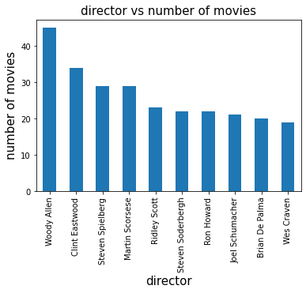

```python
# let vizualize this

data.groupby('director')['original_title'].count().sort_values(ascending=False).head(10).plot(kind='bar')
plt.title('director vs number of movies', fontsize=15)
plt.xlabel('director', fontsize =15)
plt.ylabel('number of movies', fontsize=15);
```

QUESTION 2:

Is movie popularity has to do with it profit generated

```python
# first let create profit column for the dataset
data['profit'] = data['revenue_adj'] - data['budget_adj']
```

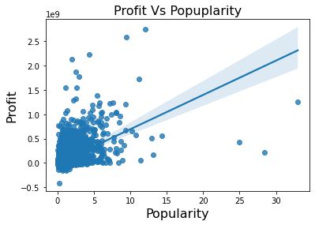

```python
# let create viz between profit and popularity by creating a function


def equation(dframe, x, y, title, xlabel, ylabel):
    sns.regplot(data=dframe, x=x, y=y)
    plt.title(title, fontsize=16)
    plt.ylabel(ylabel, fontsize=16)
    plt.xlabel(xlabel, fontsize=16)

equation(data, 'popularity', 'profit', 'Profit Vs Popuplarity', 'Popularity', 'Profit')
```

QUESTION 3:

let us check relationship between revenue_adj and budget_adj

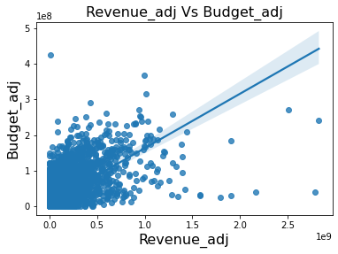

```python
# I am going to use the above function EQUATION

equation(data, 'revenue_adj', 'budget_adj', 'Revenue_adj Vs Budget_adj', 'Revenue_adj', 'Budget_adj')
```

The graph shows that as Budget_adj is increasing the revenue_adj is also increasing

QUESTION 4:

Which year has highest movies released

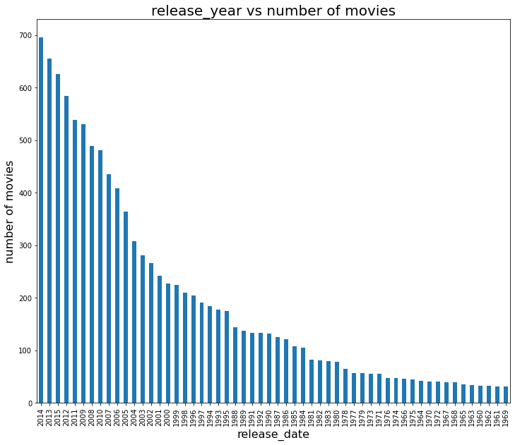

```python
# let make viz for the year with the highest number of movies released

plt.figure(figsize=[12,10])
data['release_year'].value_counts().plot(kind='bar')
plt.xlabel('release_date', fontsize=16)
plt.ylabel('number of movies', fontsize= 16)
plt.title('release_year vs number of movies', fontsize=20);
```

From the graph above, we can deduce that 2014 is the year with the highest number of movie releases

QUESTION 5:

Which movie generated highest number of revenue

```python
#let sort the dataset by the revenue generated in descending order
data.sort_values(by='revenue', ascending=False)
```

|  | popularity | budget | revenue | original_title | cast | director | runtime | production_companies | release_date | vote_count | vote_average | release_year | budget_adj | revenue_adj | movie_kind | profit |
| --- | --- | --- | --- | --- | --- | --- | --- | --- | --- | --- | --- | --- | --- | --- | --- | --- |
| 1386 | 9.432768 | 237000000 | 2781505847 | Avatar | Sam Worthington\|Zoe Saldana\|Sigourney Weaver\|S... | James Cameron | 162 | Ingenious Film Partners\|Twentieth Century Fox ... | 2009-12-10 | 8458 | 7.1 | 2009 | 2.408869e+08 | 2.827124e+09 | Action | 2.586237e+09 |
| 3 | 11.173104 | 200000000 | 2068178225 | Star Wars: The Force Awakens | Harrison Ford\|Mark Hamill\|Carrie Fisher\|Adam D... | J.J. Abrams | 136 | Lucasfilm\|Truenorth Productions\|Bad Robot | 2015-12-15 | 5292 | 7.5 | 2015 | 1.839999e+08 | 1.902723e+09 | Action | 1.718723e+09 |
| 5231 | 4.355219 | 200000000 | 1845034188 | Titanic | Kate Winslet\|Leonardo DiCaprio\|Frances Fisher\|... | James Cameron | 194 | Paramount Pictures\|Twentieth Century Fox Film ... | 1997-11-18 | 4654 | 7.3 | 1997 | 2.716921e+08 | 2.506406e+09 | Drama | 2.234714e+09 |
| 4361 | 7.637767 | 220000000 | 1519557910 | The Avengers | Robert Downey Jr.\|Chris Evans\|Mark Ruffalo\|Chr... | Joss Whedon | 143 | Marvel Studios | 2012-04-25 | 8903 | 7.3 | 2012 | 2.089437e+08 | 1.443191e+09 | Science Fiction | 1.234248e+09 |
| 0 | 32.985763 | 150000000 | 1513528810 | Jurassic World | Chris Pratt\|Bryce Dallas Howard\|Irrfan Khan\|Vi... | Colin Trevorrow | 124 | Universal Studios\|Amblin Entertainment\|Legenda... | 2015-06-09 | 5562 | 6.5 | 2015 | 1.379999e+08 | 1.392446e+09 | Action | 1.254446e+09 |
| ... | ... | ... | ... | ... | ... | ... | ... | ... | ... | ... | ... | ... | ... | ... | ... | ... |
| 4610 | 0.402405 | 0 | 0 | What Richard Did | Jack Reynor\|Roisin Murphy\|Sam Keeley\|Gavin Dre... | Lenny Abrahamson | 87 | NaN | 2012-09-09 | 17 | 4.9 | 2012 | 0.000000e+00 | 0.000000e+00 | Drama | 0.000000e+00 |
| 4609 | 0.402947 | 0 | 0 | Eden | Jamie Chung\|Beau Bridges\|Matt O'Leary\|Tantoo C... | Megan Griffiths | 98 | Eden Productions | 2012-03-11 | 32 | 6.5 | 2012 | 0.000000e+00 | 0.000000e+00 | Drama | 0.000000e+00 |
| 4608 | 0.403624 | 0 | 0 | I Am Bruce Lee | Bruce Lee\|Linda Lee Cadwell\|Shannon Lee\|Dan In... | Pete McCormack | 90 | NaN | 2012-02-09 | 14 | 7.0 | 2012 | 0.000000e+00 | 0.000000e+00 | Documentary | 0.000000e+00 |
| 4607 | 0.404069 | 0 | 0 | Rosewood Lane | Rose McGowan\|Lauren VÃ©lez\|Ray Wise\|Lin Shaye\|... | Victor Salva | 81 | Hollywood Media Bridge | 2012-01-01 | 12 | 5.0 | 2012 | 0.000000e+00 | 0.000000e+00 | Horror | 0.000000e+00 |
| 10865 | 0.035919 | 19000 | 0 | Manos: The Hands of Fate | Harold P. Warren\|Tom Neyman\|John Reynolds\|Dian... | Harold P. Warren | 74 | Norm-Iris | 2066-11-15 | 15 | 1.5 | 1966 | 1.276423e+05 | 0.000000e+00 | Horror | -1.276423e+05 |

10822 rows × 16 columns

```python
data[data['profit'] == data['profit'].max()]['original_title']
```

```
1329    Star Wars
Name: original_title, dtype: object
```

LIMITATION:

For the completion of this project I made used of Udacity classroom lecture which I followed painstainkly, also I consult some text also sought help from some youtube channels.